# Guide to giving feedback for data analytics

## How feedback helps

For learning, it is critical to have feedback so you know which areas you need improvement on and also how to improve it. There are two processes you can get feedback on: internally or externally.

The **internal feedback** is about *self-evaluation* and *self-reflection*. You will be asking yourself question such as:

1. Does your number crunching make sense?
2. Does the code behave as you expect? You may include checks or tests to make sure the behaviour is as expected.
3. Do your sentences make grammatical sense?
4. Does your narrative flow well? Why did you select the tables/graphs for display? What is the main message? Who is the narrative for? How would the audience read the narrative?
5. Does your analysis make technical sense?

There is a limit to internal feedback and can only be improved by **external feedback**. In particular, the technical correctness must be assessed by an expert; and whether your narrative as you perceive it is aligned with others’ perception requires external validation.

Providing external feedback to others can also give you internal feedback. You’ll come to realise some style of presentation is harder to understand. This will consequently help you rethink of what to do or not to do when you present your own analysis. Essentially, your experience on being on the readership/evaluation side helps to you to see how your writing is interpreted by others.

## How to give constructive feedback

**An external feedback is valuable if it’s a feedback that you wouldn’t be able to achieve via internal feedback.** Feedback like correcting your spelling mistakes or simple grammatical mistakes is not worthless but if it’s achievable using say a spell checker or grammar checker (e.g. Grammarly), then it probably was something that the author should have picked up during their internal feedback.

A **high-value feedback** will help the author identify

1. *what they are doing well*;
2. their needed area of improvement and
3. how they can improve.

**Example 1:**

From the report being evaluated:

> Out of a total of 552 players that featured in the 2019 World Cup, 15 play domestic football in Barcelona (Spain), 14 play for Lyon (France) and 12 play for Chelsea (England). It is interesting to note that clubs with 11 or higher number in this table can play in a match with a squad that’s comprised entirely of world cup internationals, greatly increasing the profile of their club’s brand.

Feedback:

*This is well written. It features a numerical summary and an interesting insight is followed up in the second sentence. The only suggestion for improvement will be to use inline R codes so the numbers (e.g. 552, 14, 12) are entered by code.*

**Example 2:**

From the report being evaluated:

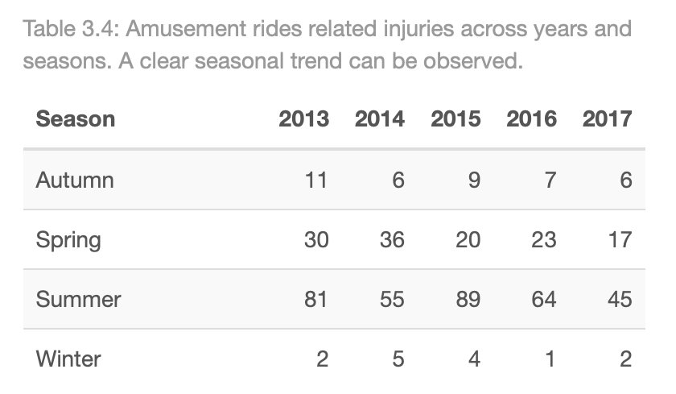

Feedback:

*This is nicely formatted table: numbers are right-aligned and text is left-aligned appropriately. The caption describes the table contents appropriately. It would be informative to add marginal totals, particularly for the columns, and add proportions of the year within the table body, in parentheses. This would help to digest the seasonal trend across years. A revised table might look like:*

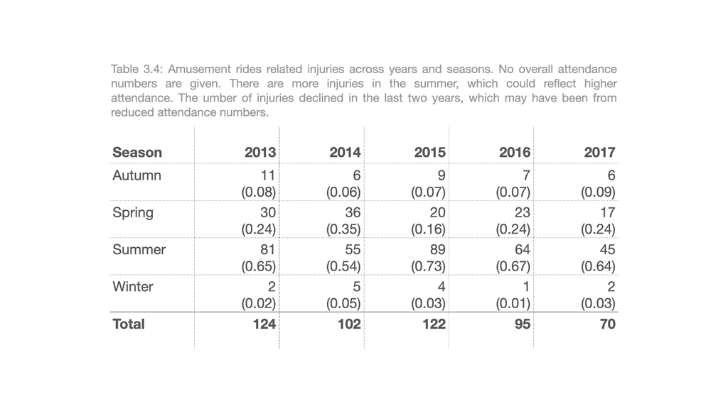

**Example 3:**

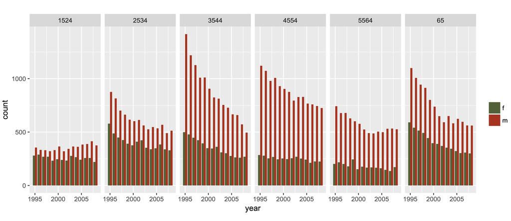

Feedback:

*Consider improving the plot in several ways: (1) Facet by gender as well so that it is easier to read the temporal trend for women, which is currently partially masked by the male trends; (2) Using a filled bar chart by gender would allow better comparison of the proportion of incidence; (3) Consider collecting population counts of the overall demographics, so that the incidence can be converted to relative risk in the general population. This is more important for age, because there are different numbers of people in the older age groups. Although the high raw counts for older people indicates an at risk population, it is probably even worse - the proportion of TB among older people is much much higher than that for younger people.*

*Some small things that could be done include (1) using better labels on the facets as age:15-24, … (2) remove the axis labels “year” and “count” because these are obvious and waste space, (3) shift the legend to be below the x axis to use more horizontal space for displaying data.*

## Using GitHub to provide feedback

### Pulling a copy

Grab a copy, simply, by downloading a **zip**’d file of the repo you are to evaluate.

### Creating an issue

The [**Issues** tab on a GitHub repo](https://guides.github.com/features/issues/) is a convenient place to provide feedback on a project. Provide your feedback by creating a new issue for the relevant repository.